# Analysis of Mean Values

For this homework, we are looking at the data from the Rice Rivers Center. Here we will be testing individual, pairs, and complete sets of mean values using `t.test` and `aov` values. Start by loading in the raw data.

```r
source("getRiceData.R")
data <- getRiceData()
```

Complete the following tests.

1. Test the null hypothesis that the average overnight air temperatures (say between 7am & 7pm) on all Mondays in January & February were above freezing. *Describe your results verbally with the aid of the statistics, visualization, or whatever you feel will help you make your point*.

```r
data %>%
  filter( month( Date ) < 3 ) %>%
  filter( Weekday  == "Monday" ) %>%
  filter( hour( Date ) >= 7 & hour( Date ) <= 19 )  %>%
  select( AirTemp ) %>%
  t.test( mu = 0, alternative = "greater" )
```

```
    One Sample t-test

data:  .
t = 30.347, df = 415, p-value < 2.2e-16
alternative hypothesis: true mean is greater than 0
95 percent confidence interval:
 6.746602      Inf
sample estimates:
mean of x
 7.134148
```

```r
data %>%
  filter( Weekday %in% c("Saturday","Sunday"),
          month( Date ) == 2 ) -> weekend

data %>%
filter( !(Weekday %in% c("Saturday","Sunday")),
          month( Date ) == 2 ) -> weekday

t.test( x = weekend$H2O_TempC, y= weekday$AirTemp, aalternative = "less" )
```

```
    Welch Two Sample t-test

data:  weekend$H2O_TempC and weekday$AirTemp
t = 8.2633, df = 2655.5, p-value < 2.2e-16
alternative hypothesis: true difference in means is not equal to 0
95 percent confidence interval:
 0.9760322 1.5833717
sample estimates:
mean of x mean of y
 5.039714  3.760012
```

3. Are there differences in the average rain recorded each weekeay at the Rice Rivers Center? *Describe your results verbally with the aid of the statistics, visualization, or whatever you feel will help you make your point*.

```r
fit.aov <- aov( Rain ~ Weekday, data=data)
fit.aov
```

```
Call:
   aov(formula = Rain ~ Weekday, data = data)

Terms:
                 Weekday Residuals
Sum of Squares  0.012150  3.310406
Deg. of Freedom        6      8192

Residual standard error: 0.0201023
Estimated effects may be unbalanced
```

```r
anova( fit.aov )
```

|  | Df | Sum Sq | Mean Sq | F value | Pr(>F) |
| --- | --- | --- | --- | --- | --- |
| Weekday | 6 | 0.01214993 | 0.0020249883 | 5.011078 | 3.89871e-05 |
| Residuals | 8192 | 3.31040628 | 0.0004041023 | NA | NA |

```r
fit.tuk <- TukeyHSD( fit.aov )
fit.tuk
```

```
  Tukey multiple comparisons of means
    95% family-wise confidence level

Fit: aov(formula = Rain ~ Weekday, data = data)

$Weekday
                            diff           lwr           upr     p adj
Tuesday-Monday     -0.0014353646 -0.0039054806  1.034751e-03 0.6068343
Wednesday-Monday   -0.0036626135 -0.0060847615 -1.240466e-03 0.0001688
Thursday-Monday    -0.0017540198 -0.0042038310  6.957914e-04 0.3457948
Friday-Monday      -0.0025642535 -0.0050343695 -9.413748e-05 0.0358967
Saturday-Monday    -0.0020527257 -0.0045228417  4.173903e-04 0.1778272
Sunday-Monday      -0.0037636979 -0.0062338139 -1.293582e-03 0.0001443
Wednesday-Tuesday  -0.0022272489 -0.0046493969  1.948991e-04 0.0953880
Thursday-Tuesday   -0.0003186552 -0.0027684664  2.131156e-03 0.9997524
Friday-Tuesday     -0.0011288889 -0.0035990049  1.341227e-03 0.8292183
Saturday-Tuesday   -0.0006173611 -0.0030874771  1.852755e-03 0.9902851
Sunday-Tuesday     -0.0023283333 -0.0047984493  1.417827e-04 0.0798687
Thursday-Wednesday  0.0019085937 -0.0004928439  4.310031e-03 0.2232697
Friday-Wednesday    0.0010983600 -0.0013237880  3.520508e-03 0.8344154
Saturday-Wednesday  0.0016098878 -0.0008122602  4.032036e-03 0.4404664
Sunday-Wednesday   -0.0001010844 -0.0025232324  2.321064e-03 0.9999997
Friday-Thursday    -0.0008102337 -0.0032600449  1.639577e-03 0.9593478
Saturday-Thursday  -0.0002987059 -0.0027485171  2.151105e-03 0.9998301
Sunday-Thursday    -0.0020096781 -0.0044594893  4.401330e-04 0.1904847
Saturday-Friday     0.0005115278 -0.0019585882  2.981644e-03 0.9965043
Sunday-Friday      -0.0011994444 -0.0036695604  1.270672e-03 0.7845196
Sunday-Saturday    -0.0017109722 -0.0041810882  7.591438e-04 0.3876107
```

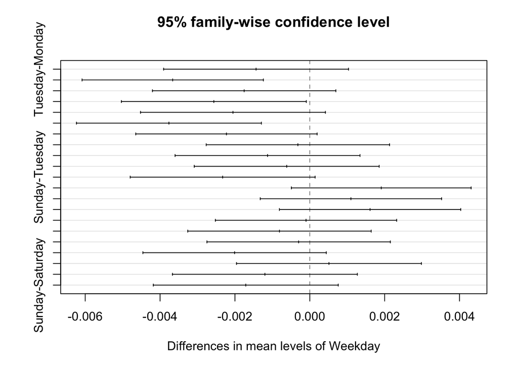

```r
plot( fit.tuk )
```